# Exploratory data analysis of Asia-Pacific political incident and conflict trends

Author

Risk Anticipation Hub

Published

August 30, 2024

## 1. Introduction

This report documents observed conflict trends in the Asia-Pacific region over the past ten years, exploring trends relating to events, fatalities, conflict types and conflict actors using ACLED data[^1].

Important to note here that this report stayed ACLED’s broad categorisation of conflict, which encompasses multiple aspects of political conflict, including protests, riots, battles, explosions and remote violence and strategic development (such as arrests of key figures).

### 1.1 Conflict events and fatalities (broad trends)

Major conflict-affected countries in the region are all quite clear: Afghanistan, Pakistan, Bangladesh, India, Thailand, Philippines and Myanmar, as are the “hotspots” within them (e.g. Kashmir) that account for some of these countries being on the list whilst not necessarily being considered to be in “in armed conflict” at the country level.

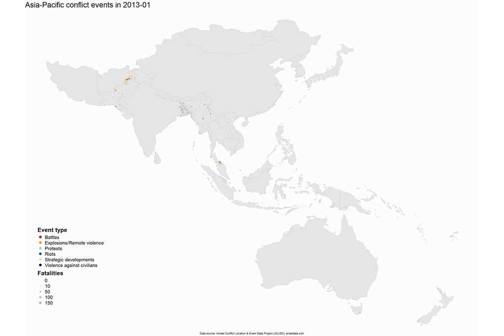

Figure 1

Looking back at a 10-year horizon (note that ACLED used to monitor a smaller set of countries) in Table 1, although the number of events is much higher than 10 years ago, the majority of countries have seen declines in the number of fatalities associated with political conflict.

The exception to is being Myanmar (civil war and post-coup escalation). Nepal also saw an increase in fatalities, but the number remains too small to draw any strong conclusions.

Table 1: 10 years of conflict: comparison 2014 and 2023

| country | events_2014 | events_2023 | events_diff% | fatalities_2014 | fatalities_2023 | fatalities_diff% |
| --- | --- | --- | --- | --- | --- | --- |
| Myanmar | 899 | 13,232 | 1,371.86 | 501 | 16,060 | 3,105.59 |
| Nepal | 250 | 2,490 | 896.00 | 6 | 10 | 66.67 |
| Sri Lanka | 158 | 894 | 465.82 | 7 | 7 | 0.00 |
| Bangladesh | 1,123 | 2,693 | 139.80 | 391 | 337 | -13.81 |
| Pakistan | 4,201 | 8,536 | 103.19 | 5,419 | 2,333 | -56.95 |
| Thailand | 1,304 | 608 | -53.37 | 424 | 57 | -86.56 |
| Vietnam | 47 | 17 | -63.83 | 29 | 10 | -65.52 |
| Cambodia | 270 | 90 | -66.67 | 23 | 0 | -100.00 |
| Total | 8,253 | 28,562 | 246.08 | 6,800 | 18,814 | 176.68 |

Myanmar, Indonesia, Iran and Bangladesh have all experienced a significant increase in unrest in the past five years. Though unrest in these countries is less bloody than before, with the exceptions of Myanmar and Pakistan. Developed democracies such as South Korea and Japan also saw large increases in political conflict, but these activities were not associated with any deaths.

Table 2: 5 years of conflict: comparison 2019 and 2023

| country | events_2019 | events_2023 | events_diff% | fatalities_2019 | fatalities_2023 | fatalities_diff% |
| --- | --- | --- | --- | --- | --- | --- |
| Myanmar | 1,815 | 13,232 | 629.04 | 1,512 | 16,060 | 962.17 |
| Indonesia | 1,644 | 3,570 | 117.15 | 210 | 214 | 1.90 |
| North Korea | 19 | 37 | 94.74 | 9 | 12 | 33.33 |
| Iran | 2,602 | 4,066 | 56.26 | 478 | 214 | -55.23 |
| Bangladesh | 1,738 | 2,693 | 54.95 | 391 | 337 | -13.81 |
| Japan | 1,299 | 1,792 | 37.95 | 0 | 0 | 0.00 |
| South Korea | 5,493 | 6,321 | 15.07 | 0 | 0 | 0.00 |
| Pakistan | 7,686 | 8,536 | 11.06 | 1,157 | 2,333 | 101.64 |
| Thailand | 568 | 608 | 7.04 | 174 | 57 | -67.24 |
| India | 23,672 | 22,865 | -3.41 | 1,529 | 1,213 | -20.67 |
| Sri Lanka | 954 | 894 | -6.29 | 304 | 7 | -97.70 |
| Mongolia | 94 | 87 | -7.45 | 0 | 0 | 0.00 |
| Cambodia | 98 | 90 | -8.16 | 5 | 0 | -100.00 |
| Nepal | 3,242 | 2,490 | -23.20 | 49 | 10 | -79.59 |
| Malaysia | 224 | 155 | -30.80 | 15 | 0 | -100.00 |
| Philippines | 1,901 | 1,251 | -34.19 | 1,706 | 855 | -49.88 |
| China | 2,516 | 1,647 | -34.54 | 13 | 9 | -30.77 |
| Vietnam | 58 | 17 | -70.69 | 1 | 10 | 900.00 |
| Afghanistan | 8,373 | 1,465 | -82.50 | 23,413 | 1,125 | -95.19 |
| Hong Kong | 1,235 | 96 | -92.23 | 1 | 0 | -100.00 |
| Total | 65,235 | 71,914 | 10.24 | 30,969 | 22,456 | -27.49 |

The increase in the number of events – especially if it was due primarily to protests – is not an immediate cause for concern. South Koreans have managed to enact several changes through their protests (like the removal of President Park Geun-hye), as have Malaysians and Nepalese.

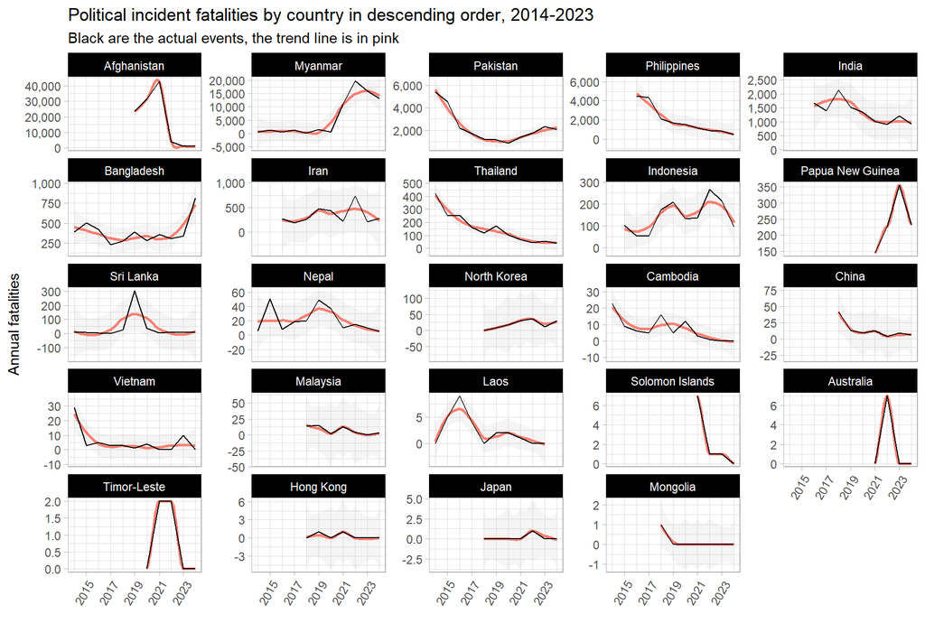

Figure 2

## Footnotes

[^1]: The primary dataset used is the Armed Conflict Location and Event Data (ACLED). The primary reason for privileging this source over UCDP’s Georeferenced Event Dataset is because ACLED has a wider diversity of sources and records a wider range of conflict events.